# Jyoti_das_updated_AIML_ML_Project_Full_Code_Notebook

### *Observation*

The observations from the distribution_plot_wrt_target for Age, Experience, Income, and CCAvg concerning Personal_Loan:

1. `Age vs. Personal_Loan:` Observation:
- - The distribution plots (histograms and box plots) for Age by Personal_Loan acceptance show that both groups (those who accepted the loan and those who did not) have a similar age distribution. There isn't a significant shift in the median age or the overall spread between the two groups. This suggests that Age, by itself, might not be a strong differentiating factor for personal loan acceptance.
2. `Experience vs. Personal_Loan:` Observation:
- - Similar to Age, the Experience distributions for both Personal_Loan groups are largely overlapping. The median experience and the overall range are quite similar for customers who accepted a loan and those who didn't. This reinforces the idea that professional experience alone is not a strong predictor of personal loan acceptance.
3. `Income vs. Personal_Loan:` Observation:
- - This is a significant one! The distribution of Income for customers who accepted a personal loan (Personal_Loan = 1) is notably shifted towards higher income values compared to those who did not (Personal_Loan = 0). The median income for loan accepters is considerably higher, and their distribution is skewed towards higher income brackets. This clearly indicates that customers with higher incomes are much more likely to accept a personal loan.
4. `CCAvg vs. Personal_Loan:`
- - Observation: The CCAvg (Average Credit Card Spending) distribution also shows a clear difference. Customers who accepted a personal loan tend to have a higher average credit card spending compared to those who did not. The median CCAvg for loan accepters is higher, and their distribution is generally shifted to the right. This suggests that customers with higher credit card spending are more prone to accepting a personal loan.

In summary, Income and CCAvg show a strong positive relationship with Personal_Loan acceptance, while Age and Experience do not appear to be significant differentiating factors.

## Data Preprocessing

- Missing value treatment
- Feature engineering (if needed)
- Outlier detection and treatment (if needed)
- Preparing data for modeling
- Any other preprocessing steps (if needed)

### Missing value treatment

#### *Observations*

- - `During our initial data overview, we checked for missing values across all columns, and the results (data.isnull().sum()) showed that there are no missing values in the dataset. So, we don't need to perform any missing value treatment steps`

### Feature Engineering: Dropping `ID` column

```python
# Dropping the 'ID' column as it is just an identifier and does not contribute to the prediction
data = data.drop('ID', axis=1)

print("DataFrame after dropping ID column:")
display(data.head())
```

```
DataFrame after dropping ID column:
```

|  | Age | Experience | Income | ZIPCode | Family | CCAvg | Education | Mortgage | Personal_Loan | Securities_Account | CD_Account | Online | CreditCard |
| --- | --- | --- | --- | --- | --- | --- | --- | --- | --- | --- | --- | --- | --- |
| 0 | 25 | 1 | 49 | 91 | 4 | 1.6 | 1 | 0 | 0 | 1 | 0 | 0 | 0 |
| 1 | 45 | 19 | 34 | 90 | 3 | 1.5 | 1 | 0 | 0 | 1 | 0 | 0 | 0 |
| 2 | 39 | 15 | 11 | 94 | 1 | 1.0 | 1 | 0 | 0 | 0 | 0 | 0 | 0 |
| 3 | 35 | 9 | 100 | 94 | 1 | 2.7 | 2 | 0 | 0 | 0 | 0 | 0 | 0 |
| 4 | 35 | 8 | 45 | 91 | 4 | 1.0 | 2 | 0 | 0 | 0 | 0 | 0 | 1 |

### *Observations*

- - We dropped the 'ID' column because it is a unique identifier for each customer and does not contain any predictive information that would help our model determine if a customer will accept a personal loan. Including ID in the model would just add noise and complexity without contributing to its ability to learn patterns and make predictions.

### Outlier detection and treatment (if needed)

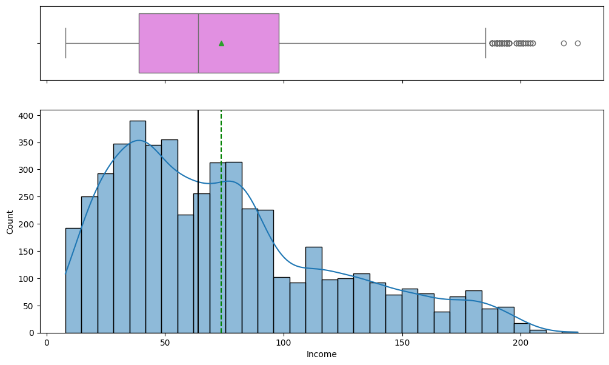

```python
histogram_boxplot(data, 'Income')
```

### *Observations*

- - As observed in the box plot for `Income`, there are many data points above the upper whisker, indicating the presence of outliers. Depending on the modeling approach, these outliers might need to be treated (e.g., capped, transformed, or removed) or some models might be robust to them.

```python
Q1 = data.select_dtypes(include=["float64", "int64"]).quantile(0.25)  # To find the 25th percentile and 75th percentile.
Q3 = data.select_dtypes(include=["float64", "int64"]).quantile(0.75)

IQR = Q3 - Q1  # Inter Quantile Range (75th perentile - 25th percentile)

lower = (
    Q1 - 1.5 * IQR
)  # Finding lower and upper bounds for all values. All values outside these bounds are outliers
upper = Q3 + 1.5 * IQR
(
    (data.select_dtypes(include=["float64", "int64"]) < lower)
    | (data.select_dtypes(include=["float64", "int64"]) > upper)
).sum() / len(data) * 100
```

|  | 0 |
| --- | --- |
| Age | 0.00 |
| Experience | 0.00 |
| Income | 1.92 |
| Family | 0.00 |
| CCAvg | 6.48 |
| Mortgage | 5.82 |
| Personal_Loan | 9.60 |

**dtype:** float64

### *Observations*

- `Income:` Approximately 1.92% of the values in the Income column are considered outliers. This aligns with our visual inspection of the Income box plot, which showed a right-skewed distribution with some higher-end outliers.
- `CCAvg:` About 6.48% of the values in CCAvg are outliers. This is also consistent with our box plot, where CCAvg showed significant right-skewness and many data points beyond the upper whisker.
- `Mortgage:` Approximately 5.82% of the Mortgage values are outliers. This is expected given the large number of zero values and some very high mortgage values we observed in its distribution.
- `Personal_Loan:` This column shows 9.60% outliers. Since Personal_Loan is a binary (0 or 1) variable and represents our target, this 'outlier' percentage here refers to the proportion of the minority class (customers who accepted the loan).It's not an outlier in the traditional sense of extreme values but rather an indicator of class imbalance.
- `Age, Experience, Family:`
- These columns show 0.00% outliers, indicating that within their respective distributions, there are no values falling outside the calculated IQR bounds.

This analysis confirms the presence of outliers in Income, CCAvg, and Mortgage, which might need further attention depending on the modeling approach chosen.

### *Preparing data for modeling*

```python
# dropping Experience as it is perfectly correlated with Age
X = data.drop(["Personal_Loan", "Experience"], axis=1)
Y = data["Personal_Loan"]

X = pd.get_dummies(X, columns=["ZIPCode", "Education"], drop_first=True)

X = X.astype(float)

# Splitting data in train and test sets
X_train, X_test, y_train, y_test = train_test_split(
    X, Y, test_size=0.30, random_state=1
)
print("Shape of Training set : ", X_train.shape)
print("Shape of test set : ", X_test.shape)
print("Percentage of classes in training set:")
print(y_train.value_counts(normalize=True))
print("Percentage of classes in test set:")
print(y_test.value_counts(normalize=True))
```

```
Shape of Training set :  (3500, 17)
Shape of test set :  (1500, 17)
Percentage of classes in training set:
Personal_Loan
0    0.905429
1    0.094571
Name: proportion, dtype: float64
Percentage of classes in test set:
Personal_Loan
0    0.900667
1    0.099333
Name: proportion, dtype: float64
```

### *Observations*

The observations from the data preparation steps:

- `Feature Selection:` Dropping the Personal_Loan column, which is our target variable, from X and stored it in Y. We also dropped the Experience column from X because it is perfectly correlated with Age, which can cause multicollinearity issues in some models. Keeping both wouldn't add new information and could be redundant.
- `One-Hot Encoding:` Categorical features ZIPCode and Education were converted into numerical format using one-hot encoding (pd.get_dummies). drop_first=True was used to avoid multicollinearity by dropping one of the dummy variables for each category.
- `Data Type Conversion:` The entire X DataFrame was converted to a float type, ensuring all features are numerical for model compatibility.
- `Data Splitting:` The dataset was successfully split into training (70%) and testing (30%) sets with a random_state=1 for reproducibility.
- `Shape of Training Set:` X_train has 3500 rows and 17 columns, while y_train has 3500 rows.
- `Shape of Test Set:` X_test has 1500 rows and 17 columns, while y_test has 1500 rows.
- `Class Imbalance Check:` The percentage of classes in both the training and test sets indicates a class imbalance, with approximately 90.5% and 90.1% respectively belonging to the Personal_Loan = 0 class, and around 9.5% and 9.9% to the Personal_Loan = 1 class. This imbalance is consistent across both sets and is important to consider during model building. Now, the data is prepared and ready for model building!

## Model Building

### Model Evaluation Criteria

Before building our models, it's crucial to establish clear evaluation criteria. For this classification problem, especially given the class imbalance (only ~9.6% loan acceptance), common metrics like accuracy alone can be misleading.

We will focus on the following metrics to assess model performance:

- **Accuracy**: The proportion of correctly predicted instances out of the total. While generally useful, its interpretation needs care with imbalanced data.
- **Precision**: The proportion of true positives among all positive predictions. High precision indicates a low false positive rate, which is important for optimizing marketing spend.
- **Recall (Sensitivity)**: The proportion of true positives among all actual positive instances. High recall means the model is good at identifying all actual loan acceptors, minimizing missed opportunities.
- **F1-Score**: The harmonic mean of precision and recall. It provides a balanced measure, particularly useful for imbalanced datasets.
- **Confusion Matrix**: A table summarizing correct and incorrect predictions for each class, providing insights into where the model is making errors (True Positives, True Negatives, False Positives, False Negatives).

To streamline our evaluation, let's create two helper functions: one for calculating these metrics and another for plotting the confusion matrix.

```python
# defining a function to compute different metrics to check performance of a classification model built using sklearn

model=LogisticRegression(random_state=1)
def model_performance_classification_sklearn(model, predictors, target):
    """
    Function to compute different metrics to check classification model performance

    model: classifier
    predictors: independent variables
    target: dependent variable
    """

    # predicting using the independent variables
    pred = model.predict(predictors)

    acc = accuracy_score(target, pred)  # to compute Accuracy
    recall = recall_score(target, pred)  # to compute Recall
    precision = precision_score(target, pred)  # to compute Precision
    f1 = f1_score(target, pred)  # to compute F1-score

    # creating a dataframe of metrics
    df_perf = pd.DataFrame(
        {"Accuracy": acc, "Recall": recall, "Precision": precision, "F1": f1,},
        index=[0],
    )

    return df_perf
```

```python
def confusion_matrix_sklearn(model, predictors, target):
    """
    To plot the confusion_matrix with percentages

    model: classifier
    predictors: independent variables
    target: dependent variable
    """
    y_pred = model.predict(predictors)
    cm = confusion_matrix(target, y_pred)
    labels = np.asarray(
        [
            ["{0:0.0f}".format(item) + "\n{0:.2%}".format(item / cm.flatten().sum())]
            for item in cm.flatten()
        ]
    ).reshape(2, 2)

    plt.figure(figsize=(6, 4))
    sns.heatmap(cm, annot=labels, fmt="")
    plt.ylabel("True label")
    plt.xlabel("Predicted label")
```

### Decision Tree (sklearn default)

```python
model = DecisionTreeClassifier(criterion="gini", random_state=1)
model.fit(X_train, y_train)
```

```
DecisionTreeClassifier(random_state=1)
```

### Checking model performance on training data

```python
confusion_matrix_sklearn(model, X_train, y_train)
decision_tree_perf_train = model_performance_classification_sklearn(
    model, X_train, y_train
)
decision_tree_perf_train
```

[output not shown]

|  | Accuracy | Recall | Precision | F1 |
| --- | --- | --- | --- | --- |
| 0 | 1.0 | 1.0 | 1.0 | 1.0 |

### Visualizing the Decision Tree

```python
feature_names = list(X_train.columns)
print(feature_names)
```

```
['Age', 'Income', 'Family', 'CCAvg', 'Mortgage', 'Securities_Account', 'CD_Account', 'Online', 'CreditCard', 'ZIPCode_91', 'ZIPCode_92', 'ZIPCode_93', 'ZIPCode_94', 'ZIPCode_95', 'ZIPCode_96', 'Education_2', 'Education_3']
```

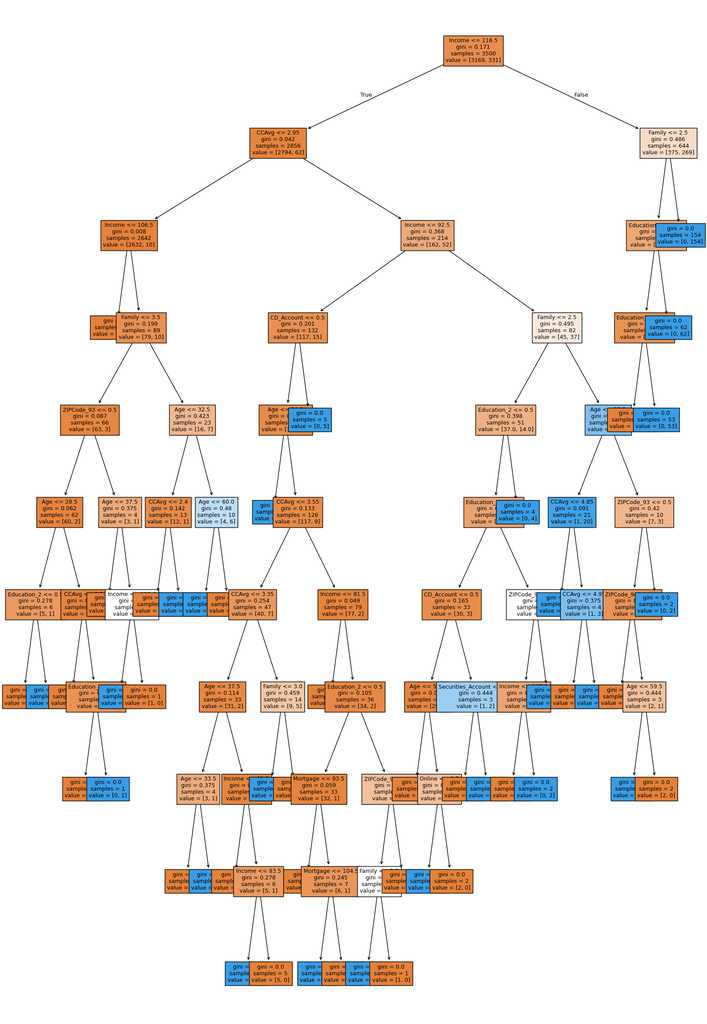

```python
plt.figure(figsize=(20, 30))
out = tree.plot_tree(
    model,
    feature_names=feature_names,
    filled=True,
    fontsize=9,
    node_ids=False,
    class_names=None,
)
# below code will add arrows to the decision tree split if they are missing
for o in out:
    arrow = o.arrow_patch
    if arrow is not None:
        arrow.set_edgecolor("black")
        arrow.set_linewidth(1)
plt.show()
```

```python
# Text report showing the rules of a decision tree -

print(tree.export_text(model, feature_names=feature_names, show_weights=True))
```

```
|--- Income <= 116.50
|   |--- CCAvg <= 2.95
|   |   |--- Income <= 106.50
|   |   |   |--- weights: [2553.00, 0.00] class: 0
|   |   |--- Income >  106.50
|   |   |   |--- Family <= 3.50
|   |   |   |   |--- ZIPCode_93 <= 0.50
|   |   |   |   |   |--- Age <= 28.50
|   |   |   |   |   |   |--- Education_2 <= 0.50
|   |   |   |   |   |   |   |--- weights: [5.00, 0.00] class: 0
|   |   |   |   |   |   |--- Education_2 >  0.50
|   |   |   |   |   |   |   |--- weights: [0.00, 1.00] class: 1
|   |   |   |   |   |--- Age >  28.50
|   |   |   |   |   |   |--- CCAvg <= 2.20
|   |   |   |   |   |   |   |--- weights: [48.00, 0.00] class: 0
|   |   |   |   |   |   |--- CCAvg >  2.20
|   |   |   |   |   |   |   |--- Education_3 <= 0.50
|   |   |   |   |   |   |   |   |--- weights: [7.00, 0.00] class: 0
|   |   |   |   |   |   |   |--- Education_3 >  0.50
|   |   |   |   |   |   |   |   |--- weights: [0.00, 1.00] class: 1
|   |   |   |   |--- ZIPCode_93 >  0.50
|   |   |   |   |   |--- Age <= 37.50
|   |   |   |   |   |   |--- weights: [2.00, 0.00] class: 0
|   |   |   |   |   |--- Age >  37.50
|   |   |   |   |   |   |--- Income <= 112.00
|   |   |   |   |   |   |   |--- weights: [0.00, 1.00] class: 1
|   |   |   |   |   |   |--- Income >  112.00
|   |   |   |   |   |   |   |--- weights: [1.00, 0.00] class: 0
|   |   |   |--- Family >  3.50
|   |   |   |   |--- Age <= 32.50
|   |   |   |   |   |--- CCAvg <= 2.40
|   |   |   |   |   |   |--- weights: [12.00, 0.00] class: 0
|   |   |   |   |   |--- CCAvg >  2.40
|   |   |   |   |   |   |--- weights: [0.00, 1.00] class: 1
|   |   |   |   |--- Age >  32.50
|   |   |   |   |   |--- Age <= 60.00
|   |   |   |   |   |   |--- weights: [0.00, 6.00] class: 1
|   |   |   |   |   |--- Age >  60.00
|   |   |   |   |   |   |--- weights: [4.00, 0.00] class: 0
|   |--- CCAvg >  2.95
```

[output cut: 90 more lines]

```
|   |   |   |   |   |   |   |--- Age >  59.50
|   |   |   |   |   |   |   |   |--- weights: [2.00, 0.00] class: 0
|   |   |   |   |   |--- ZIPCode_93 >  0.50
|   |   |   |   |   |   |--- weights: [0.00, 2.00] class: 1
|--- Income >  116.50
|   |--- Family <= 2.50
|   |   |--- Education_3 <= 0.50
|   |   |   |--- Education_2 <= 0.50
|   |   |   |   |--- weights: [375.00, 0.00] class: 0
|   |   |   |--- Education_2 >  0.50
|   |   |   |   |--- weights: [0.00, 53.00] class: 1
|   |   |--- Education_3 >  0.50
|   |   |   |--- weights: [0.00, 62.00] class: 1
|   |--- Family >  2.50
|   |   |--- weights: [0.00, 154.00] class: 1
```

```python
# importance of features in the tree building ( The importance of a feature is computed as the
# (normalized) total reduction of the criterion brought by that feature. It is also known as the Gini importance )

print(
    pd.DataFrame(
        model.feature_importances_, columns=["Imp"], index=X_train.columns
    ).sort_values(by="Imp", ascending=False)
)
```

```
                         Imp
Income              0.308098
Family              0.259255
Education_2         0.166192
Education_3         0.147127
CCAvg               0.048798
Age                 0.033150
CD_Account          0.017273
ZIPCode_94          0.007183
ZIPCode_93          0.004682
Mortgage            0.003236
Securities_Account  0.002224
Online              0.002224
ZIPCode_91          0.000556
CreditCard          0.000000
ZIPCode_92          0.000000
ZIPCode_96          0.000000
ZIPCode_95          0.000000
```

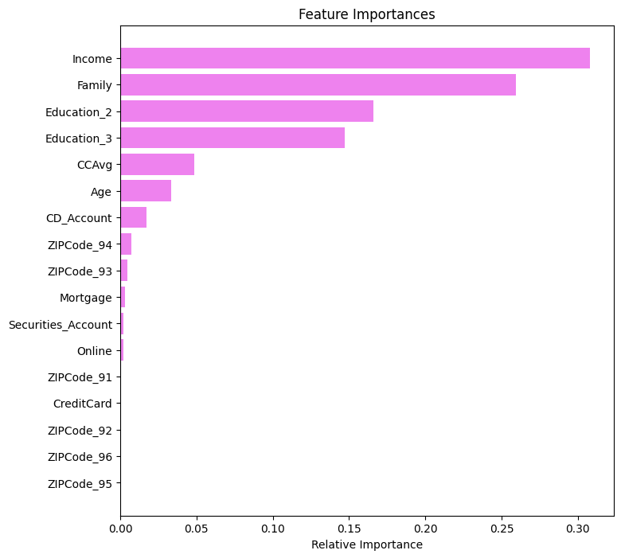

```python
importances = model.feature_importances_
indices = np.argsort(importances)

plt.figure(figsize=(8, 8))
plt.title("Feature Importances")
plt.barh(range(len(indices)), importances[indices], color="violet", align="center")
plt.yticks(range(len(indices)), [feature_names[i] for i in indices])
plt.xlabel("Relative Importance")
plt.show()
```